# London Bike Shares

Alexandra Chronopoulou

Lecture 4 Example

### Introduction to Multiple Linear Regression

In this example, we are going to fit a multiple linear regression model using the *London Bike Sharing* data set. The data is acquired from 3 sources between 1/1/2015 to 31/12/2016:

- https://cycling.data.tfl.gov.uk/ : contains *OS data © Crown copyright and database rights [2016]* and *Geomni UK Map data © and database rights [2019]* Powered by TfL Open Data
- https://i-weather.com: contains weather data
- https://www.gov.uk/bank-holidays: contains data regarding holidays in the UK

The data from cycling dataset is grouped by “Start time”, this represent the count of new bike shares grouped by hour. The long duration shares are not taken in the count. The data can be downloaded from the course website (filename: `bikeshares.csv`).

Let’s start by importing the data into R:

```r
bikeshares <-  read.csv("BikeShares.csv", header=TRUE)
dim(bikeshares)
```

```
## [1] 17414    10
```

The `bikeshares` data frame has 17414 rows and 10 columns; specifically, it contains the following variables:

- `timestamp` - timestamp field for grouping the data
- `cnt` - the count of a new bike shares
- `t1` - real temperature in C
- `t2` - temperature in C “feels like”
- `hum` - humidity in percentage
- `wind_speed` - wind speed in km/h
- `weather_code` - category of the weather
- `is_holiday` - boolean field - 1 holiday / 0 non holiday
- `is_weekend` - boolean field - 1 if the day is weekend
- `season` - category field meteorological seasons: 0-spring ; 1-summer; 2-fall; 3-winter.

The `weather_code` category description: 1 = Clear, mostly clear but have some values with haze/fog/patches of fog/ fog in vicinity; 2 = scattered clouds / few clouds; 3 = Broken clouds; 4 = Cloudy; 7 = Rain/ light Rain shower/ Light rain; 10 = rain with thunderstorm; 26 = snowfall; 94 = Freezing Fog.

### 1. Descriptive Statistics

In order to get a better idea of the data we print parts of the data set:

```r
head(bikeshares)
```

```
##             timestamp cnt  t1  t2   hum wind_speed weather_code is_holiday
## 1 2015-01-04 00:00:00 182 3.0 2.0  93.0        6.0            3          0
## 2 2015-01-04 01:00:00 138 3.0 2.5  93.0        5.0            1          0
## 3 2015-01-04 02:00:00 134 2.5 2.5  96.5        0.0            1          0
## 4 2015-01-04 03:00:00  72 2.0 2.0 100.0        0.0            1          0
## 5 2015-01-04 04:00:00  47 2.0 0.0  93.0        6.5            1          0
## 6 2015-01-04 05:00:00  46 2.0 2.0  93.0        4.0            1          0
##   is_weekend season
## 1          1      3
## 2          1      3
## 3          1      3
## 4          1      3
## 5          1      3
## 6          1      3
```

Because in this example we want to focus on regression of a continuous response against continuous predictors, we are going to “ignore” all the categorical variables from our study. We will also remove the timestamp, since for our purposes it is not needed. For convenience, we create a new dataframe containing only the information we want:

```r
# We remove columns 1,  7, 8, 9, 10:
bikeshares.reg = bikeshares[,c(-1,-7,-8,-9,-10)]
head(bikeshares.reg)
```

```
##   cnt  t1  t2   hum wind_speed
## 1 182 3.0 2.0  93.0        6.0
## 2 138 3.0 2.5  93.0        5.0
## 3 134 2.5 2.5  96.5        0.0
## 4  72 2.0 2.0 100.0        0.0
## 5  47 2.0 0.0  93.0        6.5
## 6  46 2.0 2.0  93.0        4.0
```

*Remark* The categorical variables can (and should) be included in a regression model. This is something that we will discuss later in the course when we introduce ANCOVA models.

Let us obtain the summary statistics for the tailored data set:

```r
summary(bikeshares.reg)
```

```
##       cnt             t1              t2             hum
##  Min.   :   0   Min.   :-1.50   Min.   :-6.00   Min.   : 20.50
##  1st Qu.: 257   1st Qu.: 8.00   1st Qu.: 6.00   1st Qu.: 63.00
##  Median : 844   Median :12.50   Median :12.50   Median : 74.50
##  Mean   :1143   Mean   :12.47   Mean   :11.52   Mean   : 72.32
##  3rd Qu.:1672   3rd Qu.:16.00   3rd Qu.:16.00   3rd Qu.: 83.00
##  Max.   :7860   Max.   :34.00   Max.   :34.00   Max.   :100.00
##    wind_speed
##  Min.   : 0.00
##  1st Qu.:10.00
##  Median :15.00
##  Mean   :15.91
##  3rd Qu.:20.50
##  Max.   :56.50
```

We also prepare various pairwise scatter plots:

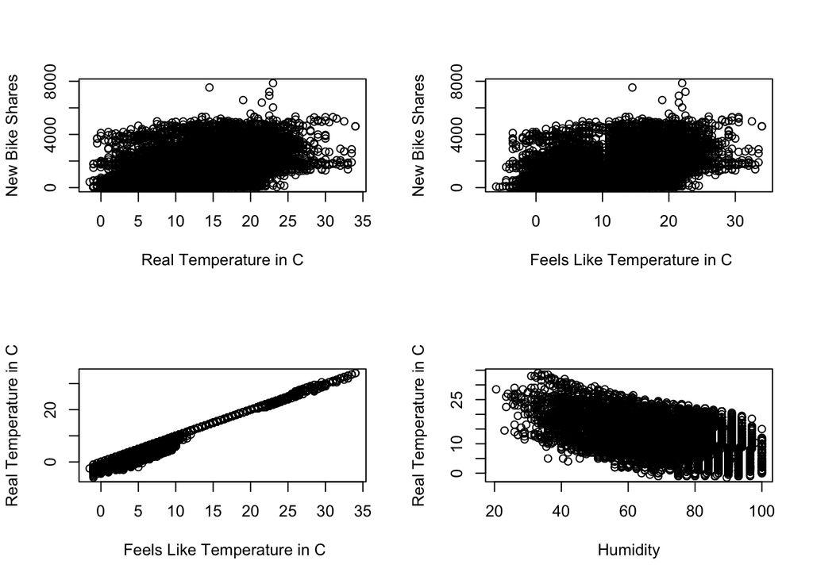

```r
par(mfrow=c(2,2))
# Plot of t1 vs. cnt
plot(bikeshares.reg$t1, bikeshares.reg$cnt, xlab="Real Temperature in C", ylab="New Bike Shares")
# Plot of t2 vs. cnt
plot(bikeshares.reg$t2, bikeshares.reg$cnt, xlab=" Feels Like Temperature in C", ylab="New Bike Shares")
# Plot of t1 vs. t2
plot(bikeshares.reg$t1, bikeshares.reg$t2, xlab=" Feels Like Temperature in C", ylab="Real Temperature in C")
# Plot of hum vs. t1
plot(bikeshares.reg$hum, bikeshares.reg$t1, xlab="Humidity", ylab="Real Temperature in C")
```

Look at the plot between *Real* temperature and *Feels Like* temperature. What do you observe?

### 2. Simple Linear Regression

```r
bikeshare.slr = lm(cnt ~ t2 , data=bikeshares.reg )
summary(bikeshare.slr)
```

```
##
## Call:
## lm(formula = cnt ~ t2, data = bikeshares.reg)
##
## Residuals:
##     Min      1Q  Median      3Q     Max
## -1820.3  -686.5  -234.2   440.2  6207.6
##
## Coefficients:
##             Estimate Std. Error t value Pr(>|t|)
## (Intercept)  445.697     15.349   29.04   <2e-16 ***
## t2            60.534      1.155   52.39   <2e-16 ***
## ---
## Signif. codes:  0 '***' 0.001 '**' 0.01 '*' 0.05 '.' 0.1 ' ' 1
##
## Residual standard error: 1009 on 17412 degrees of freedom
## Multiple R-squared:  0.1362, Adjusted R-squared:  0.1361
## F-statistic:  2745 on 1 and 17412 DF,  p-value: < 2.2e-16
```

### 3. Multiple Linear Regression

Now, let’s try to explain the “bike shares” (i.e. `cnt`) by introducing 3 more variables (i.e. `t1`, `t2`, `hum`, `wind_speed`) in the model by fitting a MLR.

```r
bikeshare.mlr1 = lm(cnt ~ t1 + t2 + hum + wind_speed, data=bikeshares.reg )
summary(bikeshare.mlr1)
```

```
##
## Call:
## lm(formula = cnt ~ t1 + t2 + hum + wind_speed, data = bikeshares.reg)
##
## Residuals:
##     Min      1Q  Median      3Q     Max
## -1970.1  -602.7  -252.7   332.6  6007.4
##
## Coefficients:
##              Estimate Std. Error t value Pr(>|t|)
## (Intercept) 2582.5618    64.7237  39.901  < 2e-16 ***
## t1            66.1963     9.4206   7.027 2.19e-12 ***
## t2           -18.2313     7.7565  -2.350 0.018762 *
## hum          -27.5645     0.5865 -46.999  < 2e-16 ***
## wind_speed    -3.8435     0.9899  -3.883 0.000104 ***
## ---
## Signif. codes:  0 '***' 0.001 '**' 0.01 '*' 0.05 '.' 0.1 ' ' 1
##
## Residual standard error: 936 on 17409 degrees of freedom
## Multiple R-squared:  0.2562, Adjusted R-squared:  0.256
## F-statistic:  1499 on 4 and 17409 DF,  p-value: < 2.2e-16
```

While `t2` is a significant predictor for `cnt` in SLR with a positive coefficient, the coefficient estimate for `t2` in MLR is negative, which contradicts what we had before.

Does it make sense for the SLR to suggest that `t2` has a positive effect on `cnt`, while MLR suggests the opposite? Such seemingly contradictory statements are quite common when predictors are **correlated**.

So, let’s look at the correlation matrix of the data:

```r
cor(bikeshares.reg[,-1])
```

```
##                    t1          t2        hum  wind_speed
## t1          1.0000000  0.98834422 -0.4477810  0.14547097
## t2          0.9883442  1.00000000 -0.4034951  0.08840854
## hum        -0.4477810 -0.40349514  1.0000000 -0.28778917
## wind_speed  0.1454710  0.08840854 -0.2877892  1.00000000
```

If we carefully observe the entries of the correlation matrix, we will observe that several of the correlation coefficients are high. In particular,
$$Corr(t1,t2) \approx 0.988,\,\, Corr(t1, hum) \approx -0.448$$
The issue of predictors that are correlated with other predictors in regression is called **multicollinearity**. Multicollinearity occurs when your model includes multiple factors that are correlated not just to your response variable, but also to each other. In other words, it results when we include factors that are a bit redundant. This correlation leads to increased standard errors, coefficients with signs opposite from what we would expect and insignificant results when they should be significant.

From a mathematical point of view, multicollinearity implies that one of the predictors can be expressed as a linear combination of the other two which leads to **rank deficiency in the design matrix**.

### 3. How to handle rank defficiency?

Sometimes, we may have redundant predictors, i.e., one predictor is equal to a linear combination of some other predictors. Then, the design matrix `X` is not of full rank. The consequence is that the inverse of `(X’X)` does not exist, so we cannot compute the LS estimate $\hat{\beta}$.

For example, to make things *worse* (in order to illustrate the issue), suppose we create a new variable which measures the average of the two temperatures, i.e.,
$$temp.mean = (t1+t2)/2.$$
Then, we re-run the regression with all the predictors:

```r
newbikeshares.reg = bikeshares.reg
newbikeshares.reg[, "temp.mean"] = (bikeshares.reg$t1+bikeshares$t2)/2
bikeshare.mlr2 = lm(cnt ~ t1 + t2 + hum + wind_speed + temp.mean, data=newbikeshares.reg )
summary(bikeshare.mlr2)
```

```
##
## Call:
## lm(formula = cnt ~ t1 + t2 + hum + wind_speed + temp.mean, data = newbikeshares.reg)
##
## Residuals:
##     Min      1Q  Median      3Q     Max
## -1970.1  -602.7  -252.7   332.6  6007.4
##
## Coefficients: (1 not defined because of singularities)
##              Estimate Std. Error t value Pr(>|t|)
## (Intercept) 2582.5618    64.7237  39.901  < 2e-16 ***
## t1            66.1963     9.4206   7.027 2.19e-12 ***
## t2           -18.2313     7.7565  -2.350 0.018762 *
## hum          -27.5645     0.5865 -46.999  < 2e-16 ***
## wind_speed    -3.8435     0.9899  -3.883 0.000104 ***
## temp.mean          NA         NA      NA       NA
## ---
## Signif. codes:  0 '***' 0.001 '**' 0.01 '*' 0.05 '.' 0.1 ' ' 1
##
## Residual standard error: 936 on 17409 degrees of freedom
## Multiple R-squared:  0.2562, Adjusted R-squared:  0.256
## F-statistic:  1499 on 4 and 17409 DF,  p-value: < 2.2e-16
```

Of course, when `X` has rank deficiency; we cannot discuss parameter estimation, since the LS estimates are no longer unique — there are many equally good estimates of beta which give us the same RSS.

But, if we just care about prediction, then rank deficiency doesn’t bring us any trouble. You’ll find the fitted values from the two models, with/without `temp.mean`, are the same.

```r
cbind(bikeshare.mlr1$fitted[1:5], bikeshare.mlr2$fitted[1:5])
```

```
##        [,1]      [,2]
## 1 158.12967 158.12967
## 2 152.85747 152.85747
## 3  42.50091  42.50091
## 4 -77.95731 -77.95731
## 5 126.47427 126.47427
```

Remark: The issue of multicollinearity and how to address it will be studied extensively in a couple of weeks.